# 3: Logistic regression

The data consists of two data sets retrieved from the UCI Machine Learning Repository using Student performance dataset from https://archive.ics.uci.edu/ml/datasets/Student+Performance. The data attributes include student grades, demographic, social and school related features and it was collected by using school reports and questionnaires. Two datasets are provided regarding the performance in two distinct subjects: Mathematics (mat) and Portuguese language (por). One table was students from a math course, and the other students from Portuguese course. The two datasets were combined for this analysis.

The data consists of 382 obsevations (students) and 35 variables. The 35 column names are as follows:

```
##  [1] "school"     "sex"        "age"        "address"    "famsize"
##  [6] "Pstatus"    "Medu"       "Fedu"       "Mjob"       "Fjob"
## [11] "reason"     "nursery"    "internet"   "guardian"   "traveltime"
## [16] "studytime"  "failures"   "schoolsup"  "famsup"     "paid"
## [21] "activities" "higher"     "romantic"   "famrel"     "freetime"
## [26] "goout"      "Dalc"       "Walc"       "health"     "absences"
## [31] "G1"         "G2"         "G3"         "alc_use"    "high_use"
```

Two variables are describing the student’s alcohol use. The variable “alc_use” is the average alcochol use on weekdays and weekends together. The variable “high_use” indicates if the average alcohol use is more than 2.

I chose 4 variables that I believe to have some relationship with the alcohol consumption. The variables are “sex”, “studytime”, “activities” and “romantic”. The gender (“sex”), extra-curricular activities (“activities”) and relationship status (“romantic”) are binary variables. Weekly studytime is numeric varying in 4 different categories between 1 and 10 hours. I would hypothesize that males, those who do not have extra-curricular activities, those who are not in a romantic relationship, and those with lower amounts of weekly studytime, have higher probability to high use alcohol consumption.

### *Tables and numerical evaluation of the relationships*

#### High alcohol use vs. gender

I think a barplot will describe the relationships quite well. This barplot below shows the mean of alcohol consumption according to gender. It can clearly be seen from the plot that males are the majority in larger means of alcohol consumption. This is especially clear when the mean value is 3 or higher. The summary statistic by group tells us the numbers: there are 72 males and 42 females in the high alcohol use group. This supports our hypothesis.

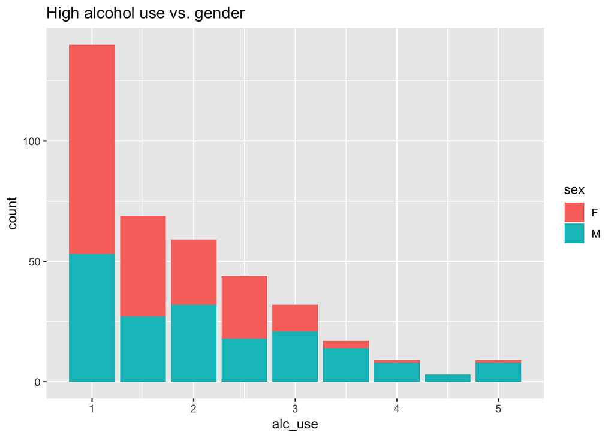

```
## # A tibble: 4 x 3
## # Groups:   sex [?]
##   sex   high_use count
##   <fct> <lgl>    <int>
## 1 F     FALSE      156
## 2 F     TRUE        42
## 3 M     FALSE      112
## 4 M     TRUE        72
```

#### High alcohol use vs. extra-curricular activities

The next barplot shows the mean of alcohol consumption according to the binary variable “activities”, which describes whether or not the individual has extra-curricular activities. This plot is not as clear as the previous one, but those who do not have extra-curricular activities are a slight majority in mean values above 2. The summary statistic by group shows that there are 59 “no’s” and 55 “yes’s” in the high alcohol use group. This supports our hypothesis, but is really small difference.

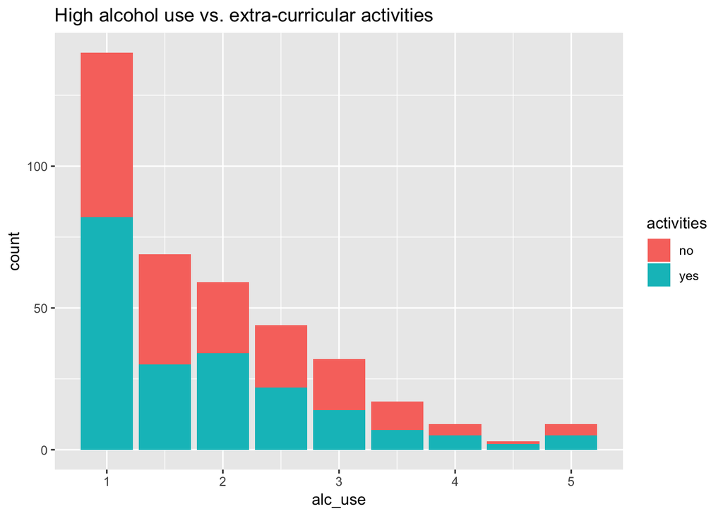

```
## # A tibble: 4 x 3
## # Groups:   activities [?]
##   activities high_use count
##   <fct>      <lgl>    <int>
## 1 no         FALSE      122
## 2 no         TRUE        59
## 3 yes        FALSE      146
## 4 yes        TRUE        55
```

#### High alcohol use vs. being in a romantic relationship

The next barplot shows the mean of alcohol consumption according to the binary variable “romantic”, which describes whether or not the individual is in a romantic relationship. This plot clearly supports our hypothesis: those who are not in a romantic relationship are the majority in mean values of 2 and higher. The summary statistic by group is also very clear to support our hypothesis by showing that in the high alcohol use group there are 81 of those who are not in a romantic relationship but only 33 of those who are in a romantic relationship.

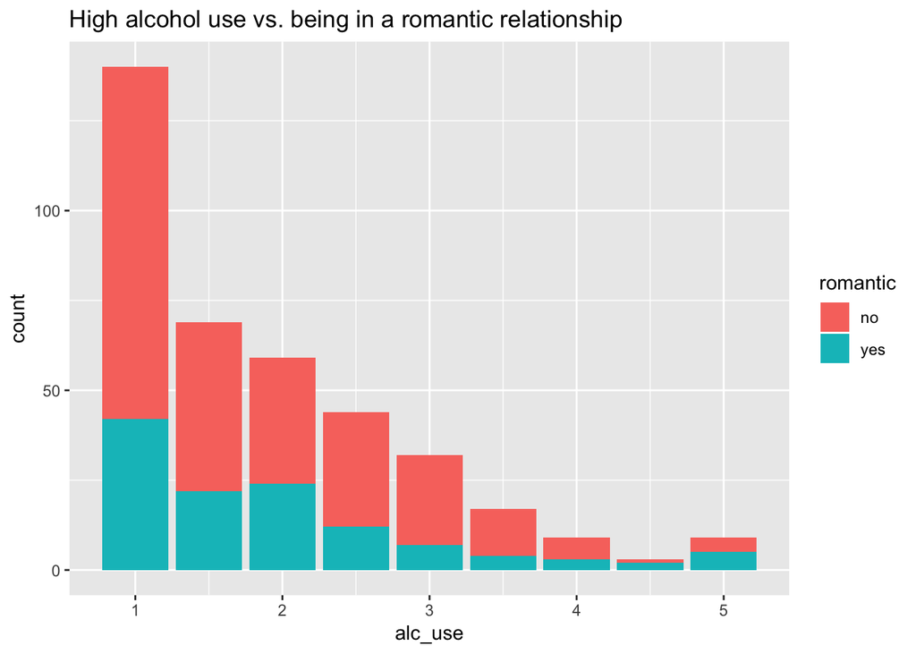

```
## # A tibble: 4 x 3
## # Groups:   romantic [?]
##   romantic high_use count
##   <fct>    <lgl>    <int>
## 1 no       FALSE      180
## 2 no       TRUE        81
## 3 yes      FALSE       88
## 4 yes      TRUE        33
```

#### High alcohol use vs. studytime

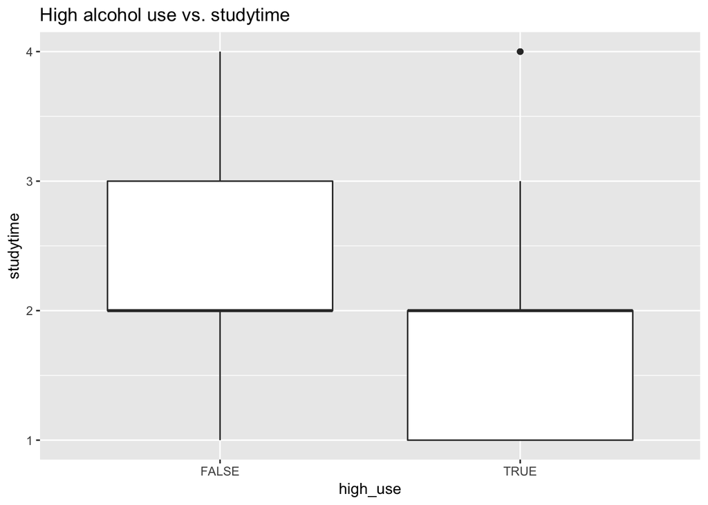

```
## # A tibble: 8 x 3
## # Groups:   studytime [?]
##   studytime high_use count
##       <int> <lgl>    <int>
## 1         1 FALSE       58
## 2         1 TRUE        42
## 3         2 FALSE      135
## 4         2 TRUE        60
## 5         3 FALSE       52
## 6         3 TRUE         8
## 7         4 FALSE       23
## 8         4 TRUE         4
```

### Logistic regression

Next I will conduct a logistic regression analysis to study the relationships between the independent variables (“sex”, “studytime”, “activities” and “romantic”) and the dependent variable (high_use: the mean alcohol use > 2). Here is the summary of the analysis:

```
##
## Call:
## glm(formula = high_use ~ sex + romantic + activities + studytime,
##     family = "binomial", data = alc2)
##
## Deviance Residuals:
##     Min       1Q   Median       3Q      Max
## -1.2083  -0.8872  -0.6806   1.1819   2.0591
##
## Coefficients:
##               Estimate Std. Error z value Pr(>|z|)
## (Intercept)   -0.17051    0.38376  -0.444  0.65681
## sexM           0.69839    0.24552   2.845  0.00445 **
## romanticyes   -0.08315    0.25272  -0.329  0.74213
## activitiesyes -0.26321    0.23571  -1.117  0.26414
## studytime     -0.45540    0.15754  -2.891  0.00384 **
## ---
## Signif. codes:  0 '***' 0.001 '**' 0.01 '*' 0.05 '.' 0.1 ' ' 1
##
## (Dispersion parameter for binomial family taken to be 1)
##
##     Null deviance: 465.68  on 381  degrees of freedom
## Residual deviance: 439.32  on 377  degrees of freedom
## AIC: 449.32
##
## Number of Fisher Scoring iterations: 4
```

```
##   (Intercept)          sexM   romanticyes activitiesyes     studytime
##    -0.1705116     0.6983944    -0.0831546    -0.2632122    -0.4553951
```

```
##
## Call:
## glm(formula = high_use ~ sex + studytime, family = "binomial",
##     data = alc2)
##
## Deviance Residuals:
##     Min       1Q   Median       3Q      Max
## -1.1429  -0.8820  -0.7177   1.2123   2.1421
##
## Coefficients:
##             Estimate Std. Error z value Pr(>|z|)
## (Intercept)  -0.2621     0.3726  -0.704  0.48169
## sexM          0.6618     0.2413   2.743  0.00610 **
## studytime    -0.4815     0.1566  -3.075  0.00211 **
## ---
## Signif. codes:  0 '***' 0.001 '**' 0.01 '*' 0.05 '.' 0.1 ' ' 1
##
## (Dispersion parameter for binomial family taken to be 1)
##
##     Null deviance: 465.68  on 381  degrees of freedom
## Residual deviance: 440.71  on 379  degrees of freedom
## AIC: 446.71
##
## Number of Fisher Scoring iterations: 4
```

```
## (Intercept)        sexM   studytime
##  -0.2621283   0.6618371  -0.4814874
```

```
##                    OR     2.5 %    97.5 %
## (Intercept) 0.7694123 0.3707640 1.6029554
## sexM        1.9383500 1.2105015 3.1228545
## studytime   0.6178637 0.4502538 0.8331592
```

This model also gives statistically significant estimates for gender and studytime. Odds ratios can be interpreted so that males are 1.94 (95% confidence interval 1.21 - 3.12) times more likely to be high users of alcohol and also that studytime increase is associated with decreasing mean of alcohol consumption (OR 0.62, 95% confidence interval 0.45 - 0.83). These both interpretations support the original hypothesis: males are more likely to be high users of alcohol and low amount of studytime is associated with higher amounts of alcohol use.